# Operating Cloud Databases

### 10.13.2 A Contact Correction and a New Event

Change the person’s email without rewriting ticket documents:

Listing 112. MongoDB shell / JavaScript

```javascript
db.people.updateOne(
  { user_id: 101 },
  { $set: { email: "maya.updated@example.org" } }
)
```

Expect one matched and one modified person. Rerun the person lookup to see the new email, then rerun the ticket lookup: its reference remains 101 and it still has no copied email field. Repeating the same correction reports one match and zero modifications. A separate `requester_name_at_open` snapshot would have a different purpose and would not automatically change with the current profile.

Now append a new synthetic follow-up event, created for this experiment rather than copied from the original CSV:

Listing 113. MongoDB shell / JavaScript

```javascript
db.history.insertOne({
  event_id: 5998, ticket_id: 1001, event_type: "note_added",
  event_at: ISODate("2026-02-03T12:00:00Z")
})
```

Repeating the latest-two query now returns 5998 and 5002. Event 5001 remains in the collection. Check the distinction between retained history and displayed history directly:

Listing 114. MongoDB shell / JavaScript

```javascript
db.history.countDocuments({ ticket_id: 1001 })
```

The result is 3. No growing array or event-ID list was added to `page_tickets`. If the application must coordinate an event with a ticket status change, however, those separate documents introduce a different problem from this independent note append. The three page reads also do not promise one atomic snapshot across all collections. State the required consistency before choosing a transaction, a retry/reconciliation design, or an acceptable delay between related changes.

### 10.13.3 Growth and the Cost of a Convenient Preview

MongoDB limits a BSON document to 16 MiB, or 16,777,216 bytes. There is no universal safe event count: event sizes, field names, and array overhead vary. An embedded history can become inconvenient well before it reaches the hard size limit, especially when a page needs only a small part of it. Fifty thousand events is a useful design stress question, not a claim that every such document exceeds the limit.

A hybrid model might keep all events in `history` and copy only two recent summaries into the ticket. The copied preview needs a maintenance rule. An out-of-order arrival should be compared by event time; an edited or deleted event may require a refreshed preview. The application must decide whether a temporarily stale preview is acceptable and how it recovers from an interrupted update. For this beginner workload, the referenced read is easier to explain and verify. A hybrid is worth considering only when its extra maintenance solves a measured need.

These choices also occur in relational systems. PostgreSQL supports arrays and JSON values, and SQL does not force every application into third normal form. Normalization remains useful for reasoning about dependencies and update anomalies; workload analysis remains useful for choosing reads and storage. The important comparison is the consequence of a specific design, not a claim that one product has flexible data while the other cannot.

## 10.14 More Than One Model Can Be Valid

Data modeling is a testable hypothesis. Document:

- most important reads;
- atomic writes;
- expected array or document growth;
- duplicated facts and their owner;
- required indexes;
- integrity rules; and
- one operation the design makes harder.

Then create representative documents and query them. A diagram without a workload is not enough.

## 10.15 Common Misconceptions

### 10.15.1 “MongoDB stores JSON exactly”

MongoDB stores BSON. Tools render BSON values using `mongosh` or Extended JSON forms.

### 10.15.2 “Embedding is denormalization, so it is always faster”

It can reduce reads but increase size, duplication, update cost, and growth risk. Measure the actual workload.

### 10.15.3 “One collection should contain every kind of document”

Flexibility permits variation; it does not remove the need for cohesive ownership, indexes, validation, and predictable queries.

### 10.15.4 “`modifiedCount: 0` means the filter failed”

The document may have matched but already contained the requested value. Inspect both matched and modified counts.

## 10.16 Study, Cleanup, and Practice

Before Day 1, read the connection, BSON, CRUD, and array-query sections. Before Day 2, read from “Single-Document Atomicity Shapes Modeling” through the event boundary example. The assigned labs use the course notebook and the specified MongoDB University units; the scenario below is optional self-study.

If you ran the shell examples, remove only the database created by their opening block and then leave the shell. This does not delete your Atlas deployment.

Listing 115. MongoDB shell / JavaScript

```javascript
db.getSiblingDB(practiceName).dropDatabase()
```

For a tutoring scheduler, compare embedded and referenced appointment notes. State the read pattern, write pattern, ownership, growth, duplication, and one query for each design.

## 10.17 Retrieval and Transfer

1. How do an Atlas project and a MongoDB database differ?
2. Why is an ObjectId not a native JSON type?
3. When does `$elemMatch` matter?
4. Why should an update filter include the expected current state?
5. Which five conditions support embedding?
6. Which workload or growth pattern would make a referenced events collection preferable?

## 10.18 Further Reading

- [MongoDB CRUD operations](https://www.mongodb.com/docs/manual/crud/)
- [MongoDB query documents](https://www.mongodb.com/docs/manual/tutorial/query-documents/)
- [MongoDB data modeling](https://www.mongodb.com/docs/manual/data-modeling/)
- [MongoDB embedding and references](https://www.mongodb.com/docs/manual/data-modeling/concepts/embedding-vs-references/)
- [MongoDB array-element matching](https://www.mongodb.com/docs/manual/reference/operator/query/elemMatch/)
- [MongoDB single-document atomicity](https://www.mongodb.com/docs/manual/core/write-operations-atomicity/)
- [MongoDB sort support from indexes](https://www.mongodb.com/docs/manual/tutorial/sort-results-with-indexes/)
- [MongoDB BSON document limits](https://www.mongodb.com/docs/manual/reference/limits/)
- [PostgreSQL arrays](https://www.postgresql.org/docs/current/arrays.html)
- [PostgreSQL JSON types and document design](https://www.postgresql.org/docs/current/datatype-json.html)
- [MongoDB University, free data-modeling course](https://learn.mongodb.com/learn/course/introduction-to-mongodb-data-modeling)

# 11 MongoDB Operations Connect Pipelines, Rules, and Indexes

## 11.1 Operating Question

How can a MongoDB workload transform documents, reject invalid states, and find the intended records without examining everything?

## 11.2 Learning Outcomes

After this module, you can:

- trace document grain through an aggregation pipeline;
- use `$match`, `$project`, `$unwind`, `$group`, `$sort`, and `$limit`;
- add focused schema validation with `$jsonSchema`;
- read basic `explain("executionStats")` measurements;
- connect a compound index to filter and sort order; and
- make a keep/remove/test-further recommendation with operational tradeoffs.

## 11.3 A Pipeline Is an Ordered Document Transformation

An active-workload report asks a different question from a ticket lookup. It needs to select active tickets, combine them into categories, count each group, and order the summaries. A pipeline makes those transformations visible. The important idea is not the number of operators: at every step, know what one output document represents.

For a complete runnable example, use the aggregation and validation notebook. It starts with four synthetic tickets and does not require a retained database. The examples in this chapter use `mongosh` JavaScript notation. In the Python notebook, operator names and field names are quoted dictionary keys, and the collection variable replaces `db.tickets`. A stage shown by itself is a fragment to place inside an aggregation array, not a complete command.

### 11.3.1 A Fresh Four-Ticket Case

For the shell examples, start a new disposable database with the complete fixture below. This is a simplified teaching case, not the full twelve-ticket relational dataset. Its categories and priorities match the notebook’s summary exercise; its event objects additionally include identifiers and dates for the later validation example. It is independent of Chapter 10’s practice database.

Listing 116. MongoDB shell / JavaScript

```javascript
const pipelinePracticeName = "cst4714_pipeline_" + ObjectId().toHexString().slice(-8);
db = db.getSiblingDB(pipelinePracticeName);
db.tickets.createIndex({ ticket_id: 1 }, { unique: true });
db.tickets.insertMany([
  {
    ticket_id: 1001, category: "streetlight", priority: "urgent", status: "open",
    subject: "Dark streetlight", assignee_id: 201,
    opened_at: ISODate("2026-02-01T00:00:00Z"),
    events: [
      { event_id: 5001, type: "created", at: ISODate("2026-02-01T00:00:00Z") },
      { event_id: 5002, type: "assigned", at: ISODate("2026-02-01T01:00:00Z") }
    ]
  },
  {
    ticket_id: 1002, category: "sanitation", priority: "high", status: "in_progress",
    subject: "Missed pickup", assignee_id: 202,
    opened_at: ISODate("2026-02-02T00:00:00Z"),
    events: [{ event_id: 5003, type: "created", at: ISODate("2026-02-02T00:00:00Z") }]
  },
  {
    ticket_id: 1003, category: "streetlight", priority: "urgent", status: "resolved",
    subject: "Lamp repaired", assignee_id: 201,
    opened_at: ISODate("2026-02-03T00:00:00Z"),
    events: [
      { event_id: 5005, type: "created", at: ISODate("2026-02-03T00:00:00Z") },
      { event_id: 5007, type: "resolved", at: ISODate("2026-02-03T02:00:00Z") }
    ]
  },
  {
    ticket_id: 1004, category: "streetlight", priority: "low", status: "new",
    subject: "Unassigned report", assignee_id: null,
    opened_at: ISODate("2026-02-04T00:00:00Z"), events: []
  }
]);
```

There are four tickets, but only three are active. The resolved urgent ticket is deliberately present so a query that counts every urgent ticket gives the wrong active-workload answer. The empty event array makes another boundary case visible without requiring a large dataset.

An aggregation pipeline passes documents through stages. Each stage receives the previous stage’s output.

Listing 117. MongoDB shell / JavaScript

```javascript
db.tickets.aggregate([
  { $match: { status: { $in: ["new", "open", "in_progress"] } } },
  {
    $group: {
      _id: "$category",
      active_count: { $sum: 1 },
      newest_opened_at: { $max: "$opened_at" }
    }
  },
  { $sort: { active_count: -1, _id: 1 } }
])
```

Trace the grain:

1. input: one document per ticket;
2. after `$match`: zero or one output per input ticket, still one per active ticket;
3. after `$group`: one document per category; and
4. after `$sort`: same documents, new order.

This is the document equivalent of reasoning about relational operations and SQL logical order.

The expected groups are streetlight with two active tickets and newest opening February 4, and sanitation with one and newest opening February 2. Ticket 1003 does not contribute because it was filtered out before grouping. The resolved ticket remains stored in the collection: this pipeline reads data and does not delete the filtered document. Pipelines can write through explicit stages such as `$merge` or `$out`, but neither appears here.

The two uses of a dollar sign are worth separating. `$group` names an operator. `"$category"` is an expression that reads the current document’s category field. Writing `"category"` instead would group every input under the same literal word. In `$sum: 1`, the number is a contribution from each input document, so the accumulator counts group members. In `$max: "$opened_at"`, each input contributes its opening date and the accumulator keeps the largest.

## 11.4 Put Selective Work Early When It Preserves Meaning

`$match` filters documents. When it appears early and matches an indexable query, MongoDB may reduce work before later stages.

`$project` selects or computes fields:

Listing 118. MongoDB shell / JavaScript

```javascript
{
  $project: {
    _id: 0,
    ticket_id: 1,
    category: 1,
    event_count: { $size: { $ifNull: ["$events", []] } }
  }
}
```

Do not project fields away before a later stage needs them. Pipeline order is meaning, not only optimization.

`$ifNull` supplies an empty array when `events` is missing or null. It does not turn an arbitrary string into an array. The `$size` expression still needs an array, which is why the fixture’s shape and later validation matter. A defensive expression must match a stated input contract rather than silently redefine bad data.

## 11.5 `$unwind` Changes One Document Into Many

Listing 119. MongoDB shell / JavaScript

```javascript
db.tickets.aggregate([
  { $match: { ticket_id: 1003 } },
  { $unwind: "$events" },
  {
    $project: {
      _id: 0,
      ticket_id: 1,
      event_type: "$events.type",
      event_at: "$events.at"
    }
  },
  { $sort: { event_at: 1 } }
])
```

After unwind, the grain is one document per array element. Ticket 1003 in this chapter has two events, so this pipeline returns two rows ordered by their dates. A ticket with three events would produce three. This is like joining a one-to-many event table: multiplication may be correct.

Use `preserveNullAndEmptyArrays` when the question should keep documents with no array elements.

### 11.5.1 A Correct Total Can Hide an Incorrect Count

Consider the separate four-ticket fixture in the Week 11 notebook. Its active tickets are 1001, 1002, and 1004. Their event-array lengths are 2, 1, and 0.

| Stream | Ticket IDs represented | Meaning of one document |
| --- | --- | --- |
| after the active filter | 1001, 1002, 1004 | one active ticket |
| after ordinary unwind | 1001, 1001, 1002 | one event inside an active ticket |

Both streams contain three documents:

$$N_{\text{tickets}} = 3,\qquad
N_{\text{events}} = 2 + 1 + 0 = 3.$$

Yet ticket 1004 vanished and ticket 1001 contributes twice. Checking only the grand total misses both mistakes. For a ticket report, aggregate before unwinding or explicitly recover distinct ticket identity. For an event report, keep the unwind and label the result as events. Preserving an empty array keeps ticket 1004 in the stream but still does not remove the duplicate contribution of 1001.

## 11.6 `$group` Creates One Document Per Group Key

Listing 120. MongoDB shell / JavaScript

```javascript
{
  $group: {
    _id: "$events.type",
    event_count: { $sum: 1 },
    latest_event_at: { $max: "$events.at" },
    ticket_ids: { $addToSet: "$ticket_id" }
  }
}
```

`_id` is the group key in this stage. `$sum`, `$avg`, `$min`, `$max`, `$push`, and `$addToSet` are common accumulators. `$group` does not guarantee output order; add `$sort` when order matters.

Grouping is a blocking operation: it may need to receive all relevant inputs before returning a group result. Filter unnecessary documents early.

Here `ticket_ids` is a set of distinct identifiers, while `event_count` counts the incoming event records. One ticket can contribute several events but only one member of that set. `$push` would instead retain repeated identifiers. Sets do not establish a presentation order; explicitly sort any output where order has meaning.

## 11.7 Worked Example: Active Workload by Agent

Listing 121. MongoDB shell / JavaScript

```javascript
db.tickets.aggregate([
  {
    $match: {
      status: { $in: ["new", "open", "in_progress"] },
      assignee_id: { $exists: true, $ne: null }
    }
  },
  {
    $group: {
      _id: "$assignee_id",
      active_count: { $sum: 1 },
      urgent_count: {
        $sum: { $cond: [{ $eq: ["$priority", "urgent"] }, 1, 0] }
      }
    }
  },
  { $sort: { active_count: -1, _id: 1 } }
])
```

Verification: choose one agent ID and run a simple `find` with the same active predicate. Count and inspect those tickets. The simpler query verifies one group through a different path.

For the chapter fixture, agent 201 has one active ticket and one urgent active ticket; agent 202 has one active ticket and no urgent active ticket. The `$cond` expression contributes 1 when the priority is urgent and 0 otherwise. Resolved ticket 1003 and unassigned ticket 1004 are outside this report. An absent agent is not represented as a zero row, just as Chapter 2’s assigned-only SQL grouping did not produce all staff. Producing a complete staff roster would require that roster as part of the query’s starting population.

## 11.8 Flexible Documents Benefit From Focused Validation

MongoDB schema validation can require types, allowed values, ranges, and selected fields. It need not make every document identical.

The following is a stronger example than the notebook’s initial three-field rule. It assumes events carry `event_id`, `type`, and `at`, as in Chapter 10. Inspect or migrate existing event objects before adopting it. Do not paste a stricter rule onto unrelated data and assume the old documents now satisfy it. `required` checks field presence; add property type rules when the event values themselves must also have a particular type.

Listing 122. MongoDB shell / JavaScript

```javascript
db.runCommand({
  collMod: "tickets",
  validator: {
    $jsonSchema: {
      bsonType: "object",
      required: ["ticket_id", "status", "priority", "subject", "opened_at"],
      properties: {
        ticket_id: { bsonType: ["int", "long"] },
        status: {
          enum: ["new", "open", "in_progress", "resolved", "closed"]
        },
        priority: {
          enum: ["low", "medium", "high", "urgent"]
        },
        subject: { bsonType: "string" },
        opened_at: { bsonType: "date" },
        events: {
          bsonType: "array",
          items: {
            bsonType: "object",
            required: ["event_id", "type", "at"]
          }
        }
      }
    }
  },
  validationLevel: "strict",
  validationAction: "error"
})
```

Existing documents must be audited before strict validation. A rule can be added with different levels and actions for migration, but a warning-only policy is not the same as rejection. Record the intended rollout.

Adding the rule does not scan and repair every existing document. `strict` and `error` describe enforcement on relevant subsequent writes. A previously stored invalid document may remain until it is identified and migrated. This differs from assuming that successful configuration proves all historical data valid.

The supplied rule requires an event to *contain* `event_id`, `type`, and `at`, but does not yet constrain their value types. The student’s notebook task begins with an even smaller rule and adds a required BSON opening date. A stronger production rule can type-check event values too. Choose the invariant you need and test both a valid and invalid write rather than declaring “schema validation is on” as the result.

For example, after applying this chapter’s rule, the following change should be rejected with validation error code 121:

Listing 123. MongoDB shell / JavaScript

```javascript
db.tickets.updateOne(
  { ticket_id: 1004 },
  { $set: { opened_at: "2026-02-04T00:00:00Z" } }
)
```

The spelling looks like a date, but the proposed value is a string. Read ticket 1004 afterward and check that its BSON Date remains. In contrast, adding an optional field such as `campus_zone: "west"` is permitted by this rule: focused validation can protect core meaning while allowing intentional variation.

MongoDB uses BSON type names such as `date`, not JSON string conventions, in validation.

## 11.9 An Index Is an Ordered Access Path for a Workload

Listing 124. MongoDB shell / JavaScript

```javascript
db.tickets.createIndex({ status: 1, opened_at: -1 })
```

This compound index is ordered by status, then opening time within status. It may support a query that filters one status and sorts newest first.

Listing 125. MongoDB shell / JavaScript

```javascript
db.tickets.find(
  { status: "open" },
  { ticket_id: 1, subject: 1, opened_at: 1 }
).sort({ opened_at: -1 }).limit(20)
```

Index order and query shape matter. An index adds storage and write work and can complicate maintenance and backups. Avoid creating one index per field without a workload.

MongoDB’s `$sort` is not stable: equal sort-key values need not keep a repeatable order. For deterministic pagination or a leaderboard, add a unique tie-breaker such as `ticket_id` to both the sort and a compatible compound index.

## 11.10 Explain Shows Plan and Execution Work

Listing 126. MongoDB shell / JavaScript

```javascript
db.tickets.find({ status: "open" })
  .sort({ opened_at: -1 })
  .limit(20)
  .explain("executionStats")
```

Important beginner measurements include:

- `nReturned`: documents returned;
- `totalDocsExamined`: documents inspected;
- `totalKeysExamined`: index keys inspected;
- `executionTimeMillis`: observed server execution time for this run; and
- winning-plan stages such as `COLLSCAN`, `IXSCAN`, `FETCH`, and `SORT`.

Explain output can differ by MongoDB version and query engine. Focus on documented meaning rather than memorizing one nested path.

A collection scan is reasonable for a tiny collection or a query needing most documents. An index scan is useful only when it reduces or orders relevant work.

Read the counts together. A hypothetical plan returning 20 documents after examining 10,000 is doing a different amount of work from one returning the same 20 after examining 20 documents and 20 index keys. The ratio of documents examined to documents returned is 500 in the first case and 1 in the second. That ratio is undefined for zero returned documents and is not a complete cost model: an index-only result, a complex sort, and repeated cached runs need context too. Check record identity before comparing speed.

On this chapter’s four-document fixture, the open-only query returns one ticket, not twenty. The limit is a maximum, and a scan can be a reasonable choice. Use the assigned MongoDB University performance activity for a larger prepared workload rather than concluding that the small local fixture demonstrates production index performance.

## 11.11 Aggregations Can Use Indexes at the Beginning

An early `$match` and compatible `$sort` may use an index before stages reshape documents. `$unwind` and `$group` can prevent later stages from using a source collection index in the same way.

For example, an index on `category` does not precompute `active_count` for every possible filter. Sorting grouped results by that newly computed count still concerns the grouped stream. Likewise, moving `$limit: 20` before a workload group would count only twenty input tickets, not compute the complete workload and then choose the twenty largest groups. A cheaper computation is useful only when it answers the same question.

Listing 127. MongoDB shell / JavaScript

```javascript
db.tickets.explain("executionStats").aggregate([
  { $match: { status: "open" } },
  { $sort: { opened_at: -1 } },
  { $limit: 20 },
  { $project: { ticket_id: 1, subject: 1, opened_at: 1 } }
])
```

Compare plans before and after the candidate index while keeping the pipeline identical.

Atlas Free does not allow aggregation disk spill and currently limits in-memory sort work to 32 MB. Keep course fixtures bounded, filter early, and use a compatible index when ordering matters. A fast result on a tiny teaching collection describes that run, not production capacity.

## 11.12 Validation and Indexing Solve Different Problems

- Validation answers: may this document state exist?
- Indexing answers: how can the DBMS find or order matching documents?
- Aggregation answers: how should input documents become output documents?

One feature does not replace the others. A fast query can return inconsistent data; valid data can still be expensive to scan.

## 11.13 Common Misconceptions

### 11.13.1 “A pipeline stage is a table”

Each stage produces a document stream. The shape and grain can change repeatedly.

### 11.13.2 “Schema validation removes flexibility”

Focused rules preserve intentional variation while rejecting known invalid types or values.

### 11.13.3 “Docs examined should always be zero”

Some queries need document fields not covered by an index. The useful comparison depends on returned results and workload.

### 11.13.4 “Moving `$match` first is always correct”

Only move a predicate before a transformation when it has the same meaning on the earlier document shape.

## 11.14 Study, Cleanup, and Practice

Before Day 1, read the pipeline and validation sections. Before Day 2, read from “An Index Is an Ordered Access Path for a Workload” through “Validation and Indexing Solve Different Problems.” The weekly labs assign the notebook change, the specific external performance activity, and the video response. The broader design exercise below is optional study practice.

If you ran the shell fixture, remove only its uniquely named practice database:

Listing 128. MongoDB shell / JavaScript

```javascript
db.getSiblingDB(pipelinePracticeName).dropDatabase()
```

Design a pipeline for one row-like output per category containing active ticket count, urgent count, and newest opening time. Annotate the grain after every stage, then propose one index for its first stages and one validation rule for its input.

## 11.15 Retrieval and Transfer

1. Which pipeline stage commonly changes one document into many?
2. What does `_id` mean inside `$group`?
3. Why audit existing documents before strict validation?
4. How do `COLLSCAN` and `IXSCAN` differ?
5. Which three execution counts help evaluate selectivity?
6. Why should a performance comparison keep the pipeline identical?

## 11.16 Further Reading

- [MongoDB aggregation stages](https://www.mongodb.com/docs/current/reference/operator/aggregation-pipeline/)
- [MongoDB `$group`](https://www.mongodb.com/docs/manual/reference/operator/aggregation/group/)
- [MongoDB schema validation](https://www.mongodb.com/docs/manual/core/schema-validation/)
- [MongoDB explain results](https://www.mongodb.com/docs/manual/reference/explain-results/)
- [MongoDB aggregation optimization](https://www.mongodb.com/docs/manual/core/aggregation-pipeline-optimization/)

# 12 Reliability Is a Set of Explicit Promises

## 12.1 Operating Question

When a managed document database has multiple nodes, which failures can it hide, which data can a client read or lose, and which separate recovery artifact still needs to exist?

## 12.2 Learning Outcomes

After this module, you can:

- explain primary, secondary, oplog, election, and failover roles in a replica set;
- distinguish read preference, read concern, and write concern;
- describe the CAP tradeoff during a network partition without using “pick any two” as a product label;
- distinguish replication from backup;
- create a free-tier-appropriate MongoDB logical recovery plan; and
- connect a reliability promise to mechanism, failure, verification, and limitation.

## 12.3 Reliability Begins With a Specific Promise

The resident presses Submit, sees a confirmation, and closes the browser. One database member fails immediately afterward. The resident’s question is not “how many servers were provisioned?” It is “does my confirmed request still exist, and can I read it?” Reliability connects a user-visible promise to the failure conditions under which the system can keep it.

“Highly available” is incomplete. A useful promise identifies:

- operation: read, write, query, restore, or reconnect;
- failure: process crash, node loss, network partition, bad deployment, or deletion;
- acceptable behavior: continue, reject, retry, use older data, or recover later;
- time or data-loss objective; and
- verification and limitation.

Example:

> A ticket write acknowledged with majority write concern should survive loss of a minority of voting data-bearing replica-set members, subject to the deployment’s durability settings. This does not protect against a later authorized deletion, so a separate logical recovery artifact is required.

## 12.4 Replica Sets Copy an Ordered Change History

A MongoDB replica set contains members that maintain the same logical dataset.

- The **primary** accepts writes under normal operation.
- **Secondaries** replicate operations from the primary’s oplog and apply them.
- The **oplog** is a bounded, ordered log of data changes used for replication.
- An **election** can choose a new primary when the old one is unavailable and a voting majority can agree.

Replication is asynchronous. A secondary can lag behind the primary. Election and client reconnection take time, so failover is not instantaneous or invisible to every operation. Drivers discover topology and retry only according to supported settings and operation semantics.

Suppose A is primary and B and C are secondaries. A write reaches A first and is then replicated. During a brief interval, B may have applied it while C has not. That does not mean the replicas are independent backups; they are catching up with the active change history. If a secondary falls farther behind than the retained oplog history can cover, normal incremental catch-up may no longer be enough and resynchronization is needed. A bounded replication log is not an indefinite archive of every historical application state.

Atlas Free uses a fixed three-node replica-set configuration, but students cannot change its replication factor or run Atlas failover testing. We analyze topology and client behavior rather than claiming to perform an unavailable test.

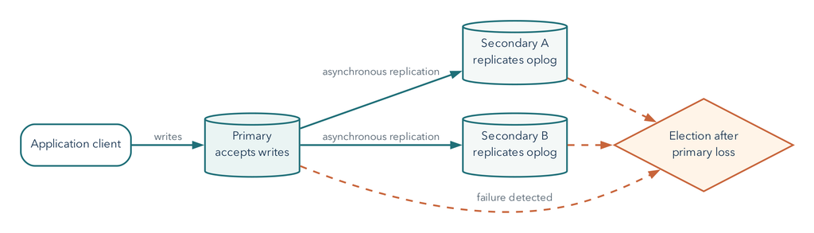

Figure 12.1: A replica set copies an ordered change history; failover requires detection, an election, and client reconnection.

## 12.5 Write Concern Defines Required Acknowledgment

Write concern describes what acknowledgment a client waits for.

The following shell example belongs in a fresh disposable database, not in the previous chapter’s validated fixture. Its stable `_id` identifies this particular submission attempt. The example observes a normal acknowledgment; it does not perform or certify a failover test.

Listing 129. MongoDB shell / JavaScript

```javascript
const reliabilityPracticeName = "cst4714_reliability_" + ObjectId().toHexString().slice(-8);
db = db.getSiblingDB(reliabilityPracticeName);
db.tickets.insertOne(
  {
    _id: "submission-1099", ticket_id: 1099,
    status: "new", subject: "Write concern test"
  },
  { writeConcern: { w: "majority", wtimeout: 5000 } }
)
```

For a typical three-member replica set, `w: "majority"` requires acknowledgment from a calculated majority of voting data-bearing members. Waiting for more acknowledgments can improve the write’s resilience to rollback but can add latency or reduce successful writes when enough members are unavailable.

A write-concern timeout means the requested acknowledgment was not received in time. It does not necessarily prove that no member applied the write. Applications need idempotent identifiers, read-back strategy, and retry rules that avoid creating duplicates.

Here the identifier gives a read-back question: does `submission-1099` exist, and does its content match the requested operation? Repeating the insert with the same identifier cannot silently create a second document with that `_id`. A duplicate-key error is not a general success signal, however; a caller must confirm that the existing record represents the same intended submission. An identifier reused for a different request would be another error.

For the ordinary three-data-bearing-member example, a majority is two. Durability also depends on journaling and the documented write-concern behavior; do not generalize this arithmetic to every voting or arbiter configuration. A `wtimeout` bounds the acknowledgment wait, not necessarily completion of the underlying write. Losing the response can leave the caller uncertain even when the write is eventually retained. [MongoDB write concern](https://www.mongodb.com/docs/manual/reference/write-concern/)

Write concern is not backup retention. A majority-acknowledged deletion is still a durable deletion.

## 12.6 Read Preference Chooses Eligible Members

Common read preference modes include:

- `primary`: read from the primary; default for normal driver reads;
- `primaryPreferred`: prefer primary, permit secondary under documented conditions;
- `secondary`: read from a secondary;
- `secondaryPreferred`: prefer a secondary, permit primary; and
- `nearest`: select among eligible members by latency window and tags.

Reading from a secondary can distribute some read work or serve locality goals, but asynchronous replication means the result may be behind the primary. A read-your-own-write workflow should not switch casually to a lagging secondary.

Read preference is routing. It is not the same as read concern.

## 12.7 Read Concern Defines Visibility Guarantees

Read concern controls the consistency and isolation properties of returned data. For example, `local` can return data from the member without guaranteeing that a majority has durably committed it; `majority` limits reads to majority-committed data under its documented semantics.

The combined behavior depends on read preference, read concern, write concern, sessions, and topology. Avoid describing a whole database as simply “consistent” or “eventually consistent” without naming the operation and settings.

Think of the three controls as separate questions: **where may I read**, **which state may that read return**, and **what must be acknowledged before my write returns**? A majority read from a lagging eligible member is not a promise that the latest possible write is immediately visible everywhere. For workflows that must read their own preceding write, MongoDB documents causal sessions with the appropriate majority read and write concerns. A primary-only read shortcut does not replace understanding failure, session, and ordering behavior. [Read isolation, consistency, and recency](https://www.mongodb.com/docs/manual/core/read-isolation-consistency-recency/)

## 12.8 CAP Is a Partition-Time Tradeoff

The CAP theorem concerns a distributed read/write data object when messages between parts of the system can be lost or delayed indefinitely.

- **Consistency** in the theorem is a single-copy/linearizable style guarantee, not the generic ACID consistency property.
- **Availability** means each operation requested at a non-failing node completes with the required operation response. Returning “unavailable” to every request is not a solution, and this definition is not a monthly uptime percentage.
- **Partition tolerance** addresses communication partitions between nodes.

When a partition separates nodes, a system cannot guarantee both that every partition continues answering every request and that all answers behave like one current copy. It must reject or delay some operations, permit potentially divergent or stale behavior, or use a more specific compromise.

“Choose two of three” is misleading because a real distributed system cannot wish network partitions away. The practical question is which operations remain available during a partition and which consistency behavior they sacrifice or preserve.

### 12.8.1 What the Partition Forces Us to Decide

Suppose A and B can communicate, but C cannot exchange messages with them. A resident’s write reaches the A/B side and completes there. A later read reaches C. C cannot know that new value by asking the other side while the partition persists. If C answers from old state, it can violate the single-current-copy promise. If it refuses to complete the read until coordination is possible, that operation is unavailable under the theorem’s definition. This is the concrete conflict, not an instruction to disable an arbitrary feature.

**Linearizability** means operations can be understood as taking effect one at a time, in an order respecting completed operations before later requests begin. It is not the same as constraints keeping each document valid. Two perfectly valid ticket documents can still show incompatible current answers to clients. The Gilbert-Lynch formalization explains the impossibility under its stated network model. Real designs specify narrower operations, bounded-staleness promises, and failure assumptions rather than replacing that result with a product slogan. [Gilbert and Lynch, 2002](https://people.cs.rutgers.edu/~rmartin/teaching/spring04/cs553/BrewersConjecture-SigAct.pdf)

## 12.9 Replication Is Not Backup

Replication helps with member failure and service continuity. It can also replicate:

- an accidental deletion;
- a bad update;
- corrupted application data;
- an authorized destructive command; or
- an unwanted schema change.

A backup or logical export creates recoverable history outside the active replica state. Recovery still needs a target, procedure, credentials, compatibility, and verification.

## 12.10 Atlas Free Requires Manual Logical Recovery

Current Atlas documentation states that native Atlas backups are unavailable for Free clusters. Free clusters also do not support sharded-cluster creation or primary-failover testing. The documented backup alternative is `mongodump` and `mongorestore`.

[figure not shown]

Figure 12.2: The Atlas Free backup screen presents paid continuous or daily backup upgrades rather than an active native backup. A free deployment therefore needs a separate logical recovery plan. Account identifiers are redacted. Interface captured August 25, 2026.

The interface shows that native backup is outside the current plan boundary; it does not represent a completed backup. Record the limitation, create a logical backup with current Database Tools, and restore it into a separate target to test the recovery procedure.

Listing 130. Shell

```bash
mongodump \
  --uri="$MONGODB_URI_NO_PASSWORD" --username="$MONGODB_USER" \
  --db="$SOURCE_DATABASE" \
  --archive=metro_support.archive.gz \
  --gzip
```

These are terminal commands, not MQL or Python cells. Set the source database to the actual practice database being exported. The URI variable must contain only connection routing/options, not a password; with a username and no supplied password, the tool prompts for it. For unattended use, Database Tools support a restricted configuration file for sensitive values. A password-bearing URI expanded into a command argument can be exposed in a process listing even when the script itself contains only a variable name. [MongoDB Database Tools](https://www.mongodb.com/docs/database-tools/mongodump/)

Inspect the exit status, file size, hash, and tool output. A logical dump taken while related collections are changing is not automatically a consistent application-wide snapshot. The course uses a small quiescent dataset. Production snapshot and oplog options have deployment-specific limits and must be evaluated separately; do not assume an Atlas Free cluster provides every option.

Restore into a different database name:

Listing 131. Shell

```bash
mongorestore \
  --uri="$MONGODB_RESTORE_URI_NO_PASSWORD" --username="$MONGODB_RESTORE_USER" \
  --archive=metro_support.archive.gz \
  --gzip \
  --stopOnError \
  --nsFrom="${SOURCE_DATABASE}.*" \
  --nsTo="${RESTORE_DATABASE}.*"
```

Review current Database Tools compatibility. Logical dumps include collection documents, metadata/options, and index definitions within documented behavior, but cluster users, project network rules, and every Atlas configuration are not simply recreated by restoring one database dump.

Choose a new restore database name and confirm it is absent before restoring. Unlike a PostgreSQL transactional restore, this command is not an all-or-nothing transaction across the archive. After an error, a partially restored target may exist. Isolate it, inspect the error, and recreate only that disposable target before repeating a corrected restore. Do not use a broad drop option on the source to make a failed test appear clean.

## 12.11 `mongoexport` Is Useful but Narrower

`mongoexport` produces JSON or CSV data suitable for interchange. It is helpful for a collection-level exercise or migration, but it is not a complete backup system. It may not preserve BSON type fidelity, collection options, validators, indexes, privileges, or a consistent multi-collection point by itself.

The course reliability notebook uses **BSON-aware Extended JSON** serialization and parsing to preserve its date values. Its data file does not by itself carry collection validators or indexes; those are examined and rebuilt separately. This transparent collection exercise is compared with `mongodump`, not mislabeled as an equivalent backup of an Atlas project. A plain JSON round trip that turns dates into strings would teach a different and incomplete recovery.

## 12.12 Verify a MongoDB Restore

Connect mongosh to the restore deployment and select the actual restore database before running these checks. Do not leave the earlier write-concern practice database selected. The expected collection names and rules come from your source manifest, not from whatever happens to appear in the current shell.

### 12.12.1 Structure and Rules

Listing 132. MongoDB shell / JavaScript

```javascript
db.getCollectionNames()
db.getCollectionInfos({ name: "tickets" })
db.tickets.getIndexes()
```

Confirm collections, validators, and required indexes.

### 12.12.2 Data and Relationships

Listing 133. MongoDB shell / JavaScript

```javascript
db.tickets.countDocuments({})
db.ticket_events.countDocuments({})
db.tickets.countDocuments({ status: "open" })
```

Trace known identifiers and check for references with no target when the model uses references.

Only expect a `ticket_events` collection when the model actually stores events separately. Counting a nonexistent collection can return zero, which is not proof that its intended backup succeeded. The recovery notebook’s source manifest names its actual collections and rules so the expected target can be checked without guessing from generic example names.

### 12.12.3 Behavior

Run one meaningful aggregation and one expected validation failure in the restore target. If recovery scope includes application access, test a temporary read and write using a least-privilege credential.

### 12.12.4 Limitation

Counts and one query do not prove every document value, historical moment, permission, or application path is correct.

## 12.13 Worked Example: Reliability Decision Matrix

**Workload:** a resident submits a ticket and immediately sees confirmation. A short delayed analytics report is acceptable. A confirmed ticket should not be silently lost after one member failure.

| Decision | Choice | Reason | Cost/limit |
| --- | --- | --- | --- |
| ticket write | majority acknowledgment with bounded timeout | stronger resilience for confirmed write | latency and possible timeout ambiguity |
| confirmation read | primary with appropriate concern/session behavior | avoid stale immediate confirmation | primary read load |
| analytics read | secondary-preferred where acceptable | stale report is tolerable | data can lag |
| accidental deletion | logical backup/restore | replication copies deletion | recovery point and restore time depend on export schedule |

The choices follow user expectations, not a universal strongest-setting rule.

## 12.14 Common Misconceptions

### 12.14.1 “Three nodes means three backups”

Replicas share the active history and can reproduce destructive changes. Backup is a separate artifact and recovery process.

### 12.14.2 “Majority write concern means the write definitely failed on timeout”

The acknowledgment condition timed out. The write may exist on some members. The application needs safe retry and verification logic.

### 12.14.3 “Secondary reads are always faster”

Topology, latency, lag, indexes, workload, and routing determine behavior. They may be stale and are not automatically faster.

### 12.14.4 “CAP says every database picks two letters forever”

The tradeoff is about behavior during a network partition under specific formal definitions.

## 12.15 Study, Cleanup, and Practice

Before Day 1, read the replication, read/write controls, and partition discussion. Before Day 2, read from “Replication Is Not Backup” through restore verification. The required lab pairs a supplied reliability decision case with the separately assigned logical-recovery notebook. The inventory matrix below is optional self-study, not another submission.

If you ran the acknowledgment example, its cleanup is:

Listing 134. MongoDB shell / JavaScript

```javascript
db.getSiblingDB(reliabilityPracticeName).dropDatabase()
```

That removes only the newly named practice database, not the Atlas deployment or an unrelated source or restore database.

Write a reliability matrix for a small inventory system. Include one critical write, one stale-tolerant read, one partition scenario, one accidental deletion, and one restore verification. For every choice, name a mechanism and limitation.

## 12.16 Retrieval and Transfer

1. What is the oplog’s role in a replica set?
2. How do write concern and read preference differ?
3. Why can a write-concern timeout produce an ambiguous application outcome?
4. What CAP decision appears only during a partition?
5. Why does a replica not replace a backup?
6. Which Atlas Free limits change the Week 12 lab design?

## 12.17 Further Reading

- [MongoDB replication](https://www.mongodb.com/docs/manual/replication/)
- [Replica-set read and write semantics](https://www.mongodb.com/docs/manual/applications/replication/)
- [MongoDB write concern](https://www.mongodb.com/docs/manual/reference/write-concern/)
- [MongoDB read concern](https://www.mongodb.com/docs/manual/reference/read-concern/)
- [Atlas Free limits](https://www.mongodb.com/docs/atlas/reference/free-shared-limitations/)
- [MongoDB `mongodump`](https://www.mongodb.com/docs/database-tools/mongodump/)
- [Gilbert and Lynch, CAP formalization](https://people.cs.rutgers.edu/~rmartin/teaching/spring04/cs553/BrewersConjecture-SigAct.pdf)

# Part IV: Scale and Integration

Scale is not merely a larger number of rows. It changes coordination, routing, capacity, cost, recovery, observability, and the number of failure combinations an operator must understand. Chapters 13-14 examine workload-based capacity, sharding decisions, safe imports, client connection contracts, polyglot persistence, event-driven propagation, and reconciliation.

The central question remains ownership of truth. A multi-database design is defensible only when each fact has an authoritative source, partial failures are expected, and a repair path is designed before an incident.

# 13 Scale Changes the Questions a System Must Answer

## 13.1 Operating Question

When data or traffic grows, how do we decide whether to tune, scale up, partition, or shard, and how can a small Python client expose the consequences?

## 13.2 Learning Outcomes

After this module, you can:

- describe capacity using workload, storage, latency, throughput, and growth;
- distinguish vertical scaling, read replicas, partitioning, and sharding;
- explain the roles of shards, replica sets, config servers, and `mongos`;
- evaluate shard-key cardinality, frequency, monotonicity, and query targeting;
- compare ranged and hashed distribution; and
- connect to a cloud database from Python without saving credentials.

## 13.3 Capacity Planning Starts With a Workload

The word scale can describe several different changes. A table can grow while traffic stays low. Traffic can grow while the dataset stays small. A once-per-day report can become an interactive request whose user will not wait. These cases stress storage, throughput, and response time differently. Buying more capacity before identifying the pressure may increase cost without improving the user experience.

“Will this database scale?” has no answer without quantities and objectives.

Record:

- current and expected records or documents;
- average and high-percentile object size;
- read and write operations by query shape;
- peak versus average throughput;
- acceptable latency and error rate;
- working set versus available memory;
- index and backup growth;
- retention and deletion behavior; and
- expected growth horizon.

A beginner project should not fabricate enterprise traffic. It should state a small current workload, one plausible growth scenario, and the first measurement that would trigger a change.

**Throughput** is completed work per unit time, such as requests per second. **Latency** is the time one request takes. A system can finish many requests per second while some users wait a long time. A percentile describes that spread: the 95th-percentile latency is a value at or below which roughly 95 percent of the measured requests fall, under the stated calculation method. It is not the average, and it says nothing about requests omitted from the measurement.

The **working set** is the data and index pages an active workload repeatedly uses. A database larger than memory can still serve a small hot working set efficiently. Conversely, adding many speculative indexes can crowd useful pages out of cache. Before changing architecture, connect the observed pressure to the actual query mix and data distribution.

## 13.4 Fix Waste Before Distributing It

Scaling options include:

- **query/model improvement:** reduce unnecessary work;
- **vertical scaling:** add CPU, memory, or faster storage to one node or tier;
- **caching:** avoid repeated work with an explicit freshness policy;
- **read replication:** serve selected reads from copies with consistency tradeoffs;
- **partitioning:** divide a logical dataset within one database system; and
- **sharding:** distribute parts of a collection or dataset across database nodes.

Horizontal distribution adds network failures, routing, rebalancing, cross-shard operations, monitoring, and recovery complexity. Do not shard a bad query merely to run the bad query on more machines.

Replication and sharding are especially easy to confuse. Replicas maintain copies of a logical dataset so a service can tolerate member failure or serve eligible reads elsewhere. Shards hold different portions of a dataset. In a sharded MongoDB deployment, each shard can itself be replicated. Adding three replicas of one dataset is not the same as dividing that dataset into three independently placed portions.

## 13.5 MongoDB Sharding Distributes Collection Ranges

A sharded MongoDB cluster includes:

- **shards:** each shard stores part of the collection and is normally a replica set for availability;
- **config servers:** store cluster metadata and configuration;
- **`mongos`:** query routers that use metadata to target shards and merge results; and
- **chunks/ranges:** non-overlapping shard-key ranges assigned across shards.

The shard key is an indexed field or compound of fields that determines document distribution. It becomes a long-lived architectural decision even though modern MongoDB supports refinement and resharding.

Atlas Free cannot create a sharded cluster. Students analyze a candidate and simulate distribution in open code rather than claiming to deploy the paid architecture.

## 13.6 Four Shard-Key Questions

### 13.6.1 Cardinality

How many distinct key values exist? A Boolean or five-value status field cannot create many independently distributable ranges by itself.

If 75 records have 75 distinct CVE identifiers but only five distinct date-added values, those candidate fields have different cardinalities. This describes the sample’s distribution, not how often users will query any particular record. Always separate a measured record distribution from an assumed traffic pattern.

### 13.6.2 Frequency

How often does each value occur? A high-cardinality key can still be skewed if one value dominates traffic or document count.

Hashing a repeated value does not split its occurrences among arbitrary shards: the same input value produces the same hash value. A key with a million identical values therefore retains that concentration under hashing. A more varied full key may be necessary; “hashed” is not a repair for every skewed model.

### 13.6.3 Monotonicity

Does the key continually increase or decrease, such as a timestamp or sequential identifier? Range sharding on a monotonic key can direct new writes toward the chunk holding the current extreme, creating a hotspot.

### 13.6.4 Query Targeting

Do common queries include the shard key? If a query does not provide enough shard- key information, the router may broadcast it to multiple shards in a scatter- gather operation.

An ideal candidate balances distribution and targeting. No single field property guarantees both.

## 13.7 Ranged and Hashed Distribution Make Different Tradeoffs

### 13.7.1 Ranged Sharding

Nearby shard-key values stay in nearby ranges. A query for a bounded range can be targeted, but monotonic inserts or skew can concentrate load.

### 13.7.2 Hashed Sharding

MongoDB hashes the shard-key value to distribute documents more evenly. This can spread monotonic identifiers, but range queries on the original values lose locality and may contact many shards.

Example:

- `{ neighborhood: 1, opened_at: 1 }` can support locality and targeted neighborhood-time queries but may skew if one neighborhood dominates.
- `{ ticket_id: "hashed" }` can distribute identifier writes but does not target a query that only filters neighborhood.

Choose from the actual query and write distribution.

Imagine sorting cards by neighborhood and date. A neighborhood/date-range question can identify a contiguous region of that arrangement. Shuffling the cards by a stable hash of ticket ID distributes nearby IDs but loses that date locality. The analogy explains the tradeoff; actual MongoDB placement also uses chunks, routing metadata, and balancing. A classroom bucket simulation is not an implementation of the server’s hash function or placement algorithm.

## 13.8 Cross-Shard Operations Cost More Coordination

A request can be:

- **targeted:** routed to one shard or limited shard set using the shard key; or
- **scatter-gather:** sent broadly and merged by `mongos`.

Cross-shard aggregations, transactions, uniqueness, and resharding can add network and coordination cost. A design can still use them; the cost should be visible.

## 13.9 Worked Example: Evaluate Metro Support Candidates

Hypothetical workload, not a measurement of the small supplied fixture:

- writes arrive across neighborhoods;
- dashboards filter neighborhood and recent opening time;
- support staff retrieve exact ticket IDs; and
- one central neighborhood produces 45 percent of tickets.

| Candidate | Distribution | Targeting | Risk |
| --- | --- | --- | --- |
| `status` | very low cardinality | helps status query only | jumbo/hot values |
| `opened_at` ranged | high and monotonic | good time ranges | latest-write hotspot |
| `ticket_id` hashed | likely even writes | exact ID target | neighborhood/time reports scatter |
| `(neighborhood, ticket_id hashed component)` | spreads within neighborhood | neighborhood queries can target a subset depending on full key | more complex routing and index |

The table does not produce a universal winner. It identifies what data and query measurements are needed before deployment.

## 13.10 Python Makes the Client Contract Visible

A driver connection includes network routing, TLS, authentication, server selection, timeouts, and query behavior. Keep the first program small.

A **driver** is the library that speaks the database protocol from a programming language. Installing it does not create a database or authorize access. The following examples assume the driver is installed and an existing personal practice database contains the stated data. The integration notebook includes installation, a bounded source, setup, and cleanup when you need the complete start-to-finish path.

### 13.10.1 MongoDB Atlas

Listing 135. Python

```python
from getpass import getpass
from pymongo import MongoClient
from pymongo.server_api import ServerApi

mongodb_uri = getpass("Atlas connection URI: ")
database_name = input("Existing practice database name: ").strip()
with MongoClient(
    mongodb_uri,
    server_api=ServerApi("1", strict=True, deprecation_errors=True),
    serverSelectionTimeoutMS=10000,
    timeoutMS=10000,
) as client:
    client.admin.command("ping")
    tickets = client[database_name]["tickets"]
    for ticket in tickets.find(
        {"status": "open"}, {"_id": 0, "ticket_id": 1}
    ).limit(20):
        print(ticket)
```

Do not add `tlsInsecure=True` as a routine fix. It disables certificate validation and can hide the real issue. Check the URI, current driver, system time, network access list, DNS, and supported TLS path.

The `with` block closes the client when the example finishes or raises an error. The query reads at most twenty matching documents and makes no changes. A successful ping with an empty result can mean that the database name is wrong, the collection is absent, or no ticket is open. Check the intended source and a known identifier instead of interpreting an empty loop as proof of a successful import. Remove the temporary runtime IP rule when cloud practice is finished.

### 13.10.2 PostgreSQL/Supabase

Listing 136. Python

```python
from getpass import getpass
import psycopg
from psycopg.conninfo import conninfo_to_dict

database_url = getpass("PostgreSQL connection URL: ")
sslmode = conninfo_to_dict(database_url).get("sslmode", "prefer")
if sslmode not in {"require", "verify-ca", "verify-full"}:
    raise ValueError("Add sslmode=require or a stronger mode to the URL.")

with psycopg.connect(database_url, connect_timeout=10) as connection:
    with connection.cursor() as cursor:
        cursor.execute("SELECT count(*) FROM metro_support.tickets")
        print(cursor.fetchone())
```

On a network without direct IPv6 connectivity, use the provider’s current IPv4- compatible session-pooler URI rather than changing database code randomly. `sslmode=require` prevents an unencrypted fallback but does not verify server identity. For production, use `verify-full` with the provider’s CA certificate.

Inside the cursor block, pass changing **values** as parameters rather than building SQL by joining strings. This fragment uses the already opened cursor:

Listing 137. Python

```python
requested_status = "open"
cursor.execute(
    "SELECT ticket_id FROM metro_support.tickets WHERE status = %s ORDER BY ticket_id",
    (requested_status,),
)
print(cursor.fetchall())
```

The `%s` is a driver placeholder; it is not an invitation to apply Python string formatting. The separate one-item tuple carries the value. The driver keeps data from becoming SQL syntax. Do not put quotes around the placeholder. Table and column **names** are identifiers, not values; dynamic identifiers require a different composition mechanism such as `psycopg.sql.Identifier`. [Psycopg parameter guide](https://www.psycopg.org/psycopg3/docs/basic/params.html)

## 13.11 Import in Small, Verifiable Batches

Before loading a public dataset:

1. inspect license, source, retrieval date, columns, types, nulls, duplicates, and size;
2. select a small subset tied to a question;
3. convert dates and missing values intentionally;
4. write a batch;
5. check acknowledged-write results or row counts; and
6. query a known sample and total.

An import script should be rerunnable or explicitly idempotent. Stable natural keys, upserts, a reset option in a disposable collection, or a recorded batch ID can prevent accidental duplicates.

**Idempotent** means repeating an operation has the same intended final effect as doing it once. An import keyed by a stable CVE identifier can update or keep that record on a second run rather than insert another copy. It must still define what happens if the source changes or a run stops partway through. Resetting an empty table before every import is a useful test setup, but it does not demonstrate idempotency: rerun the import against its existing output to test that property.

### 13.11.1 Inspect the Public Source Before Loading It

The course provides a documented 75-record selection from CISA’s Known Exploited Vulnerabilities catalog. Its metadata records a July 2026 source version and retrieval, so it is a reproducible teaching snapshot, not a current operational security feed. A CVE identifies a vulnerability record; `dateAdded` describes catalog inclusion, not necessarily the date a vulnerability was discovered or first exploited. The sample selects the first source records, not a random sample of all software vulnerabilities.

Download kev_sample.json and place it beside this Python exercise, or upload it through Colab’s Files panel. Unlike CSV, the JSON file preserves the CWE list as an array. The outer object contains source metadata; the actual records are inside its `vulnerabilities` array.

Listing 138. Python

```python
import json
from collections import Counter

with open("kev_sample.json", encoding="utf-8") as source_file:
    source = json.load(source_file)

records = source["vulnerabilities"]
ids = set()
dates = Counter()
for record in records:
    ids.add(record["cveID"])
    dates[record["dateAdded"]] += 1

print("Source version:", source["catalogVersion"])
print("Records:", len(records))
print("Distinct CVE identifiers:", len(ids))
print("Distinct date-added values:", len(dates))
print("Most frequent dates:", dates.most_common(3))
```

`set` keeps distinct identifiers; `Counter` counts how often each date occurs. The two cardinalities and the largest date counts give different information about candidate keys. None of these counts ranks vendors by security quality or measures traffic to a future application. A key can spread records well while one popular record still receives most requests.

The integration notebook takes this inspected source through one selected database path, a repeat import, and a question-driven query. Using both cloud platforms is optional. The learning target is an understandable, repeatable client-to-database workflow, not accumulating accounts.

## 13.12 Scaling Also Scales Operations

More nodes or stores mean more:

- credentials and network rules;
- metrics and alerts;
- backup components and restore order;
- version compatibility;
- failure combinations;
- cost controls; and
- people who must understand the system.

A capacity recommendation should include the operating cost, not only throughput.

A simple first-pass storage projection makes assumptions explicit. If the system starts with $D_0$ bytes, grows by $g$ bytes per day, retains $r$ days of new data, and carries an overhead multiplier $m$ for indexes, replication, and working space, then:

$$D_{\text{projected}} = (D_0 + gr)m.$$

This is not a vendor-sizing formula. It is a transparent baseline that reviewers can challenge: growth may be nonlinear, compression varies, replicas multiply physical storage, and peak working space can dominate a migration or index build.

For example, retaining an initial 100 MiB plus 20 MiB of new data per day for 30 days gives 700 MiB before overhead. An assumed factor of two gives 1,400 MiB. One MiB is 1,048,576 bytes; one MB is 1,000,000 bytes. Keep units explicit when comparing a measurement with a service quota. The multiplier is an assumption to refine, not a promise that every platform charges or accounts for replicas in that way. This formula also assumes the initial data is retained; an actual retention policy may expire some of it.

An appropriate beginner recommendation might be: “Our current data is small, so I would first measure the largest documents, index size, and the busiest query. If retained growth approaches the free quota, I would shorten justified retention, remove unnecessary copies, or evaluate another capacity tier before considering sharding.” It names a next measurement without inventing enterprise load or treating a paid upgrade as part of the assignment.

## 13.13 Common Misconceptions

### 13.13.1 “High cardinality makes a perfect shard key”

Frequency, monotonicity, query targeting, and update behavior also matter.

### 13.13.2 “Hashed sharding makes every query faster”

It can improve distribution while turning range or non-key queries into broad operations.

### 13.13.3 “A free replica set lets us practice sharding”

Replication and sharding solve different problems. Atlas Free does not support a sharded cluster.

### 13.13.4 “If a script inserted rows, the import worked”

Verify counts, known identifiers, types, and a question-driven query. Handle partial failure and reruns.

## 13.14 Study and Practice

Before Day 1, read the capacity and distribution sections through the candidate comparison and the public-source inspection example. Before Day 2, read the Python, import, and storage projection sections. The assigned notebook provides complete setup and cleanup; the candidate analysis below is optional practice rather than another report.

Evaluate three shard-key candidates for an event dataset: timestamp, device ID, and hashed event ID. For each, record cardinality, frequency, monotonicity, two query patterns, and likely distribution. Recommend what to measure next rather than inventing a final production answer.

## 13.15 Retrieval and Transfer

1. How do vertical scaling and sharding differ?
2. What does `mongos` do?
3. Why can a monotonic ranged shard key create a hotspot?
4. What is a scatter-gather query?
5. What tradeoff does hashed distribution make?
6. Which two connection practices protect credentials and TLS verification?

## 13.16 Further Reading

- [MongoDB sharding](https://www.mongodb.com/docs/manual/sharding/)
- [MongoDB shard keys](https://www.mongodb.com/docs/manual/core/sharding-shard-key/)
- [MongoDB choose a shard key](https://www.mongodb.com/docs/manual/core/sharding-choose-a-shard-key/)
- [PyMongo getting started](https://www.mongodb.com/docs/languages/python/pymongo-driver/current/get-started/)
- [Psycopg documentation](https://www.psycopg.org/psycopg3/docs/)

# 14 Multiple Databases Multiply Options and Obligations

## 14.1 Operating Question

If one application uses PostgreSQL and MongoDB, which system owns each fact, how do changes cross the boundary, and how can an incident be diagnosed without making the systems disagree further?

## 14.2 Learning Outcomes

After this module, you can:

- distinguish polyglot persistence from casual technology accumulation;
- assign one authoritative owner to each fact;
- compare synchronous dual writes, event-driven propagation, and reconciliation;
- identify consistency, security, backup, and observability obligations across systems;
- triage a cross-database incident from symptoms, logs, and stored records; and
- defend a one-platform or two-platform final-project choice.

## 14.3 Polyglot Persistence Is Workload-Based Specialization

Two screens can disagree even when both databases are healthy. The staff screen may read the authoritative ticket row while the resident screen reads a copy maintained elsewhere. This chapter follows one change between those screens. The new skill is recognizing a boundary between systems, not building a large distributed application from scratch.

A polyglot system uses different data technologies for different responsibilities. For example:

- PostgreSQL owns users, permissions, and authoritative ticket state;
- MongoDB stores flexible, high-volume event detail or read-optimized ticket snapshots; and
- an object store holds attachments.

This can fit workloads well. It also creates more deployment, access, monitoring, recovery, and consistency work. A small application should prefer one database unless the second solves a specific problem worth that cost.

## 14.4 Every Fact Needs One Authoritative Owner

If both PostgreSQL and MongoDB contain `ticket.status`, answer:

- Which copy accepts the business update?
- Which copy is derived?
- How is the derived copy refreshed?
- How stale may it be?
- How is disagreement detected and repaired?
- Which copy is used during recovery?

Without an owner, “synchronize both” becomes an undefined circular obligation. Duplication can be deliberate when one source is authoritative and the other is a cache, projection, snapshot, or historical record.

An **authoritative** record is the record whose accepted update establishes the current business fact. A **projection** is a derived representation arranged for a particular read. A **snapshot** intentionally preserves a state at a named earlier time. These are different promises. A snapshot from February is not incorrect merely because today’s authoritative value has changed; a projection advertised as current may be incorrect if it silently remains at February’s state.

Ownership can differ by fact. PostgreSQL might own ticket status while an object store owns the attachment bytes. “PostgreSQL is the source of truth” is too broad if it implies the attachment can be reconstructed from a filename alone. State which fact and which accepted update you mean.

## 14.5 Synchronous Dual Writes Create Partial-Failure Risk

Naive sequence:

1. update PostgreSQL;
2. update MongoDB; and
3. return success.

If step 1 commits and step 2 fails, the stores disagree. Reversing the order only changes which partial outcome occurs. A distributed transaction protocol can coordinate some systems but adds availability, latency, and operational cost and is not generally supplied by two unrelated cloud APIs.

Do not hide the boundary behind a broad `try/except`. Record an operation ID, preserve an authoritative result, and design retry or reconciliation.

An exception handler sees what the client observed, not necessarily what a remote service committed. If MongoDB stored the projection but its response was lost, retrying can apply the change twice unless the operation is designed for that possibility. Returning an error to the browser also does not roll back a PostgreSQL transaction that has already committed. A transaction boundary inside one database is not a transaction boundary around arbitrary network calls.

## 14.6 Event-Driven Propagation Separates Commit From Projection

One pattern:

1. begin one PostgreSQL transaction;
2. update the authoritative record and insert its outgoing event in that same transaction;
3. commit both, or roll both back;
4. after commit, a relay delivers the recorded event to a consumer;
5. the consumer applies it to the MongoDB projection; and
6. monitoring identifies undelivered work, failed application, or excessive lag.

The **transactional outbox** stores the business change and outgoing event in the same local transaction. A relay publishes unsent events. This avoids the gap where the business row commits but the event is never recorded.

An **event** is a record describing a particular change. The **relay** moves that record from the outbox to its delivery channel. The **consumer** reads delivered events and applies the intended effect. Those names identify responsibilities; they do not require three separate products in a small application.

Suppose the relay sends an event successfully but stops before recording that it was sent. On restart it can send the event again. Alternatively, a consumer can apply the change and lose its acknowledgment. A design that allows redelivery can recover from those gaps, provided repeated application is safe. Recording an event in the same transaction closes the original missing-event gap; it does not magically establish exactly-once effects across all later systems.

The consumer should be idempotent: applying the same event twice should not create duplicate effect. Use stable event IDs and record processed state or use an upsert whose final state is deterministic.

For a transformation $f_e$ applying event $e$ to state $x$, idempotency means:

$$f_e(f_e(x))=f_e(x).$$

Setting a status to a particular value can have that property. Adding one to a counter does not: applying the same increment twice changes the result twice. Even an idempotent status update can be wrong when it arrives out of order. Setting a ticket to an older `open` state twice is repeat-safe, but still wrong after a newer `resolved` state. Repetition and ordering require distinct reasoning.

Event-driven design trades immediate cross-store consistency for decoupling, retries, and observable lag. State whether that is acceptable to the user.

### 14.6.1 Try the Ordering Rule Without Cloud Infrastructure

The example below is an executable model of one projection. A **version** is a counter assigned in the authoritative order for this ticket, not the consumer’s clock time. Each event carries the complete projected status at that version. Python dictionaries stand in for stored records; no database connection is made.

Listing 139. Python

```python
projection = {"ticket_id": 1008, "status": "open", "source_version": 16}
deliveries = [
    {"status": "resolved", "source_version": 17},
    {"status": "resolved", "source_version": 17},
    {"status": "closed", "source_version": 18},
    {"status": "open", "source_version": 16},
]

for event in deliveries:
    if event["source_version"] > projection["source_version"]:
        projection["status"] = event["status"]
        projection["source_version"] = event["source_version"]
    print(projection["status"], projection["source_version"])
```

The observed states should be `resolved 17`, `resolved 17`, `closed 18`, and `closed 18`. The duplicate changes nothing, and the late version 16 cannot move the projection backward. The in-class lab lets students remove that condition and observe the regression directly.

This works for the stated full-state events. If version 17 means “add one” and version 18 means “add two,” applying only version 18 loses the earlier increment. Delta events need ordering, deduplication, or a state-reconstruction strategy appropriate to their meaning. A version number does not make arbitrary skipped operations safe.

The loop also assumes one consumer acts at a time. Two independent production consumers must not separately read an old version and then blindly write their own answers. For an existing MongoDB projection, an expected-version filter and update can compare and change the same document atomically. A missing projection needs a separate initialization policy. A zero-match result can mean “already newer” or “not present,” so those cases need to be distinguished.

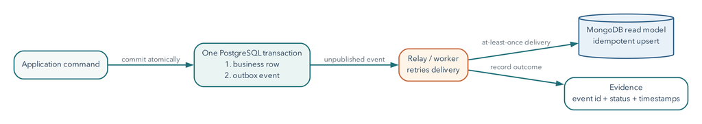

Figure 14.1: A transactional outbox records the business change and event atomically, then delivers an idempotent projection asynchronously.

## 14.7 Reconciliation Is a Designed Operation

Even a reliable pipeline needs a way to compare systems.

Useful checks include:

- counts by stable partition or date;
- missing authoritative identifiers;
- version or updated-at mismatches;
- hashes of canonical field sets;
- event offsets or last processed IDs; and
- samples of high-risk records.

Reconciliation output should identify an owner and repair direction. Blindly copying the newest timestamp can be wrong when clocks, delayed events, or manual repairs differ.

**Lag** is the gap between authoritative progress and applied projection progress. An empty queue does not necessarily prove a correct projection if failed messages were discarded. Counts can agree while field values differ, just as equal totals hid the array-counting mistake in Chapter 11. Compare stable identifiers and versions for the affected records, then broaden the check to the scope suggested by the failure.

## 14.8 Identity and Access Cross the Boundary Too

A shared application user may map to:

- a Supabase Auth identity;
- PostgreSQL roles or RLS claims;
- an application service credential;
- an Atlas database user; and
- document-level owner identifiers.

Do not give browser clients powerful Atlas or Supabase service credentials. A backend service can mediate access, but it must enforce authorization and retain least privilege in both databases.

Audit records should correlate actions through a request or operation ID without copying secrets or unnecessary personal data.

## 14.9 Backup and Restore Need an Order

Independent logical dumps taken at different moments may not represent one application-consistent point. A recovery plan must state:

- which system is authoritative;
- backup cadence and recovery point for each;
- restore order;
- how derived data is rebuilt or reconciled;
- how events are replayed without duplication; and
- how traffic remains isolated until verification.

If MongoDB contains a rebuildable projection of PostgreSQL facts, restoring PostgreSQL and regenerating the projection may be safer than treating both dumps as equally authoritative.

## 14.10 Worked Incident: Ticket State Disagrees

**Symptoms:** The resident portal shows ticket 1008 as `open`. The staff dashboard shows `resolved`. The event feed contains a `ticket_resolved` event.

**Architecture:** PostgreSQL owns ticket state. An outbox relay updates a MongoDB read projection used by the resident portal.

### 14.10.1 Incident Trace

1. Query PostgreSQL ticket 1008 and its transaction/update time.
2. Query the outbox for the stable event ID and publish status.
3. Query consumer logs or checkpoint for that event ID.
4. Query the MongoDB projection’s source version and event ID.
5. Check whether later events supersede it.

### 14.10.2 Plausible Finding

PostgreSQL and the outbox committed. The consumer failed after receiving the event but before updating the projection, and its retry queue is paused.

In the assigned incident, the later MongoDB read still shows version 16 while the authoritative row and its event are version 17. The consumer recorded a timeout and then paused because its database credential expired. The timeout by itself is ambiguous; the later record comparison establishes that this particular projection is still behind. The first repair concerns the consumer’s approved access and retry path, not reverting the correct authoritative ticket to match the stale page.

### 14.10.3 Response

Resume or replay the idempotent consumer from the recorded event. Do not manually edit both stores without recording the repair. Verify the MongoDB projection now contains the authoritative version, the event is marked processed, lag returns to normal, and no duplicate history was created.

### 14.10.4 Limitation

These observations support one incident path. They do not show that every projection is consistent; run the reconciliation check for the affected partition.

A useful update to a colleague would be: “The resident page is behind the staff record because the projection consumer is not progressing. Ticket 1008 is at authoritative version 17, while the inspected projection remains at 16. Restore the consumer’s approved access, resume safe delivery, and verify version 17 or a newer authoritative state. Then inspect the other queued tickets before closing the incident.” This explanation separates observed facts from the proposed repair; it does not claim the repair was completed before checking it.

## 14.11 Observability Should Follow a Request Across Systems

Useful signals include:

- request or operation ID;
- authoritative commit result;
- outbox backlog and oldest age;
- consumer success/failure and retry count;
- projection version lag;
- query latency and error by datastore;
- connection-pool exhaustion; and
- backup age and last restore verification.

Logs without stable identifiers make cross-system timelines guesswork. Metrics without user impact can also mislead. Connect technical observations to the failed operation.

## 14.12 A One-Database Design Is Often the Stronger Decision

Use one platform when:

- the workload fits its model and scale;
- the team is small;
- cross-store consistency would add risk;
- operational records are already difficult to correlate; or
- the second system is chosen only to appear advanced.

Use two when the workload benefit is concrete, ownership is explicit, propagation and recovery are designed, and the team can operate both.

## 14.13 Common Misconceptions

### 14.13.1 “The same ID means the records are synchronized”

Identifiers support correlation. They do not prove field equality, ordering, or successful propagation.

### 14.13.2 “Events guarantee consistency”

Events create a mechanism. Delivery, ordering, idempotency, retries, lag, and reconciliation determine behavior.

### 14.13.3 “Two backups produce one consistent recovery point”

Independent artifacts can represent different moments. Ownership and replay order must be part of the plan.

### 14.13.4 “Polyglot means using as many databases as possible”

It means matching technologies to distinct needs while accepting the operating cost.

## 14.14 Study and Practice

Before Day 1, read through the worked incident, including the event-driven example and reconciliation discussion. Before Day 2, review access, recovery, and the one-platform versus two-platform decision for the project clinic. The weekly lab combines the supplied incident with the small Python experiment in one Brightspace response. The inventory responsibility table below is optional self-study, not a second report.

Create a responsibility table for a two-store inventory system. For inventory quantity, product description, flexible event details, and user access, name the authoritative store, derived copy if any, propagation path, acceptable staleness, reconciliation check, and recovery order.

## 14.15 Retrieval and Transfer

1. Why does each duplicated fact need one authoritative owner?
2. What partial failure occurs in synchronous dual writes?
3. How does a transactional outbox reduce one failure gap?
4. What makes an event consumer idempotent?
5. Why can two independent backups be application-inconsistent?
6. Which logs and checks would diagnose projection lag?

## 14.16 Further Reading

- [Martin Fowler, Polyglot Persistence](https://martinfowler.com/bliki/PolyglotPersistence.html)
- [Microsoft Azure Architecture Center, Transactional Outbox pattern](https://learn.microsoft.com/azure/architecture/databases/guide/transactional-outbox-cosmos)
- [AWS Prescriptive Guidance, Transactional Outbox pattern](https://docs.aws.amazon.com/prescriptive-guidance/latest/cloud-design-patterns/transactional-outbox.html)
- [PostgreSQL logical decoding concepts](https://www.postgresql.org/docs/current/logicaldecoding-explanation.html)
- [MongoDB change streams](https://www.mongodb.com/docs/manual/changeStreams/)

# Part V: Professional Communication

Technical skill becomes career value when another person can inspect the decision, method, tradeoff, and result. Chapter 15 synthesizes the course into portfolio artifacts, resume bullets, interview explanations, incident stories, and next-skill plans.

The target is not an exaggerated claim of production expertise. It is a precise, credible account of what you built, what you observed, how you verified it, and which boundary you would investigate next in a larger system.

# 15 Professional Communication Makes Technical Skill Visible

## 15.1 Operating Question

How can you explain what you learned so an instructor, teammate, or interviewer can understand your actions, results, reasoning, safety, and tradeoffs rather than only seeing a list of tools?

## 15.2 Learning Outcomes

After this module, you can:

- connect course work to database, cloud, backend, data, and security roles;
- review a database system through model, query, access, performance, and recovery decisions and results;
- present a final project without exposing credentials;
- write a concise portfolio project that another person can run or inspect;
- answer technical and behavioral interview questions with specific examples; and
- identify a realistic next skill rather than claiming production mastery.

## 15.3 Make Technical Work Understandable

A course project becomes easier to discuss when another person can follow the problem, your decision, and the result. This applies to an interview, a handoff to another developer, or an explanation to the person who needs a report. It is not a request to turn every classroom exercise into a claim of production expertise. Begin with work you actually completed and understand.

Tool names matter less when they are unsupported. Compare:

> Familiar with PostgreSQL, Supabase, MongoDB, Atlas, GitHub, and Python.

with:

> Built and verified a three-table PostgreSQL schema with named integrity constraints; reproduced and diagnosed a two-session blocking incident using `pg_stat_activity` and `pg_blocking_pids`; tested a workload-driven composite index with before/after plans; and restored a logical dump into a separate target with structure, relationship, and behavior checks.

The second statement identifies actions, results, and scope. It does not claim years of production operation.

## 15.4 The Course Skill Matrix

| Workplace need | Relevant course work |
| --- | --- |
| understand a data model | relational schema, JSON alternatives, embed/reference decision |
| query and verify | SQL/MQL files, result-grain notes, aggregation checks |
| protect access | role/grant matrix, RLS allow/deny tests, credential-safe notebooks |
| investigate incidents | lock relationship, query plan, polyglot timeline |
| improve performance | unchanged workload, before/after plans, index tradeoff |
| recover data | logical artifact, separate restore, verification runbook |
| use cloud services | Supabase/Atlas shared-responsibility and free-tier decisions |
| automate carefully | small Python connection/import/recovery notebook |
| communicate | decision-result-tradeoff responses and final demonstration |

These skills can support database administration, cloud support, application support, backend development, data engineering, cybersecurity operations, and technical analysis. Job titles differ, but the underlying actions transfer.

For example, O*NET’s database-administrator profile includes activities involving database changes, access, performance, and recovery. It is a useful vocabulary reference, not a guarantee that one introductory course meets every employer’s requirements. Compare an actual posting with a particular piece of your work rather than adding all of its terms to a resume. [O*NET Database Administrators](https://www.onetonline.org/link/summary/15-1242.00)

## 15.5 Review a System Through Six Questions

1. **Purpose:** what workload and user decision does the system support?
2. **Model:** what does one record mean, and how are relationships represented?
3. **Integrity and access:** which bad states and unauthorized actions are refused?
4. **Queries and performance:** which questions matter, and what plans/indexes support them?
5. **Reliability:** what failure is tolerated, what is backed up, and how is restore verified?
6. **Reproducibility:** can another person rebuild, inspect, and explain the result without receiving a secret?

Use these questions for the final project, a portfolio review, or an interview system-design prompt.

### 15.5.1 Review by Explaining One Result

Here is a small SQL review that runs without installing the course schema. The two named results inside `WITH` supply the sample rows. It asks for each staff member’s active-ticket count, including zero. This is practice for explaining the mechanism, not another required submission.

Listing 140. SQL

```sql
WITH staff(agent_id, name) AS (
    VALUES (201, 'Priya'), (202, 'Noah'), (203, 'Elena')
),
ticket_sample(ticket_id, assignee_id, status) AS (
    VALUES (1, 201, 'open'), (2, 201, 'resolved'),
           (3, NULL::integer, 'new'), (4, 202, 'open')
)
SELECT s.agent_id, s.name, count(t.ticket_id) AS active_count
FROM staff AS s
LEFT JOIN ticket_sample AS t
    ON t.assignee_id = s.agent_id
   AND t.status IN ('new', 'open', 'in_progress')
GROUP BY s.agent_id, s.name
ORDER BY s.agent_id;
```

The result is Priya 1, Noah 1, Elena 0. There are three active tickets, but the staff counts sum to two because ticket 3 is unassigned. The left join preserves staff, not every ticket. `count(t.ticket_id)` ignores Elena’s null-extended ticket field; `count(*)` would count that row and incorrectly give her one. Moving the ticket-status condition into WHERE would remove Elena instead of preserving the zero.

That explanation contains several course ideas in a small space: a defined population, a join condition, NULL behavior, result grain, and an independent total. An interviewer can ask “what would change if …?” and you have a way to reason rather than recite a memorized definition.

The same habit transfers beyond SQL. After MongoDB `$unwind`, ask whether one document means a ticket or an event. After an access-policy change, ask which identity ran the query. After an index change, ask whether the same records were returned. After restore, ask which source state and rules were reconstructed. The product commands differ, but the reasoning is connected.

## 15.6 Present the Final Project as a Decision Story

A focused demonstration shows:

1. problem and user;
2. workload and platform choice;
3. model and one relationship decision;
4. one meaningful query and result;
5. one access, performance, or recovery decision with a concrete result;
6. one tradeoff or limitation; and
7. one next improvement.

Use prepared, redacted project outputs. Do not open a secrets page, paste a connection string, or depend on a live cloud request as the only demonstration. A short static fallback protects the presentation from network failure.

## 15.7 Build a Portfolio Project Around One Concept

A useful repository or folder does not need a complete app. It can teach one concept clearly:

Listing 141. Text

```
my-database-concept/
  README.md
  example.sql or example.ipynb   (only if useful)
```

The example may instead live entirely in fenced code blocks in the README. Multiple setup, session, and result files can be useful for a larger project, but they are not required by the final in-class concept lab. Choose the smallest package that makes your one idea understandable and reproducible.

The README should include:

- problem and learning objective;
- environment and prerequisites;
- safe run order;
- expected output;
- explanation of the result;
- cleanup;
- limitation; and
- source/license attribution.

Other strong concepts include RLS allow/deny tests, plan-based index design, logical restore verification, CSV-to-JSON model comparison, aggregation grain, or shard-key analysis.

For a Markdown-only concept guide, write the question first, show a small example and its expected result, and explain the important consequence. For a notebook, put a short explanation before each meaningful code step and interpret the result afterward. Running every cell without changing or explaining anything does not make the learning visible to another reader.

## 15.8 Remove Portfolio Risk

Before publishing:

- search for passwords, URIs, API keys, tokens, and private hostnames;
- remove real personal or regulated data;
- use readable text output or a redacted interface capture, depending on what the example needs to show;
- ensure scripts affect only a named disposable schema or collection;
- identify destructive commands prominently;
- test the run order in a clean environment; and
- include licenses and attributions.

Rotating a credential is necessary if it was exposed. Deleting the visible line is not enough because Git history may retain it.

## 15.9 Use STAR-R for Behavioral Questions

- **Situation:** concise context and impact.
- **Task:** your responsibility or decision.
- **Action:** what you personally inspected, changed, and verified.
- **Result:** observable outcome.
- **Reflection:** limitation and next production step.

Example:

> In a controlled PostgreSQL lab, one ticket update waited behind an open transaction. My task was to identify the relationship without terminating the wrong session. I queried `pg_stat_activity` and used `pg_blocking_pids`, which showed the waiting PID and one blocker whose transaction began earlier in my Session A client. I rolled back the controlled blocker, observed Session B complete, and queried the row from a fresh statement to confirm which values remained. The exercise showed the diagnostic method, but in production I would also confirm application ownership and business impact before cancellation and would review transaction timeout and workflow design.

This answer is credible because it narrows the context and names specific observations.

If you used the supplied incident transcript instead of a live connection, change the opening to “I analyzed a provided two-session incident trace.” You can still explain the blocking relationship and propose the correct check; you should not claim to have created or resolved a live wait. A precise scope statement lets the reader assess the skill you demonstrated.

### 15.9.1 Respond to a Follow-Up, Not Just the Opening Question

Suppose the interviewer asks, “Why did rollback help?” A useful answer is:

> Session A held the row lock because its transaction had not ended. Rolling it back released that lock and discarded A’s uncommitted change. Session B could then continue. I checked the final row because releasing a wait does not tell me which business values were retained.

If asked, “Would you roll back any old transaction?”, distinguish this controlled case from a production decision. Determine who owns the transaction, what work it contains, and who can authorize cancellation. Technical capability and authority to use it are separate. You can explain that distinction without having managed a production incident yourself.

## 15.10 Explain Technical Choices With Decision-Result-Tradeoff

Interview question: “Why did you add that index?”

- **Decision:** I kept a composite index on status and descending opening time for the newest-open-ticket queue.
- **Result:** On the 100,000-row fixture, the unchanged query moved from a scan plus sort to an index-supported path, removed the explicit sort, and examined far fewer rows for a 20-row result.
- **Tradeoff:** the index consumes storage and adds work to writes and backup, so I would monitor its actual usage and remove it if the workload changes.

Avoid “indexes make queries faster” without a query, plan, or cost.

Do not invent a speedup percentage from one favorable run. If the available result is a changed scan path and removal of a sort, describe those observations. If you measured repeated timings, state the fixture, query, runs, and limit of that comparison. The result need not be dramatic to demonstrate careful judgment.

## 15.11 Answer Design Questions by Stating Assumptions

Interview question: “Would you use PostgreSQL or MongoDB?”

A strong beginner response:

1. ask about access patterns, relationships, integrity, variation, scale, and recovery;
2. state an assumption;
3. choose the simpler suitable model;
4. show one alternative and tradeoff; and
5. name a test or measurement that could change the decision.

Example:

> If authoritative appointments have stable relationships and scheduling conflicts, I would begin with PostgreSQL constraints and transactions. If the system also stores highly variable, append-heavy form snapshots read as whole documents, MongoDB could own that bounded responsibility. I would not add a second store until query volume or model friction justified its synchronization and recovery cost.

## 15.12 Be Honest About Scope

Course work demonstrates foundational skill, not unsupervised production ownership. Useful phrases include:

- “I reproduced this in an isolated cloud lab…”
- “The result showed…”
- “This check did not cover…”
- “In production I would also inspect…”
- “I have not operated that feature at scale, but I can explain the decision and next measurement…”

Honest scope plus concrete reasoning is stronger than inflated certainty.

It is also reasonable not to know an unfamiliar product feature. Separate the known concept from the unverified implementation: “I have tested row-level security in PostgreSQL. I would check how this service maps an authenticated user to a database role and then run allowed and denied tests through that request path.” This proposes a technically relevant next step without pretending all platforms work identically.

## 15.13 Plan the Next Skill From a Job Posting

Choose a role family and examine several current postings. Count recurring skills, then connect one gap to a small project.

Examples:

- Linux and shell: automate a safe dump verification script.
- Python: write a small, idempotent data import with logging.
- monitoring: create a local dashboard from query and backup-age metrics.
- cloud networking: document TLS, DNS, IPv4/IPv6, and allow-list diagnostics.
- CI: validate SQL/JSON/notebooks on every repository change.

Do not chase every product. Build depth around one measurable workflow.

## 15.14 Worked Example: Turn a Lab Into a Resume Bullet

Weak:

> Used MongoDB Atlas in class.

Relevant work:

- designed embedded and referenced ticket models;
- wrote MQL filters and an aggregation;
- added validation and a compound index;
- compared `COLLSCAN`/`IXSCAN`, documents examined, and returned;
- restored a logical collection export to a separate target; and
- documented Atlas Free limitations.

Possible bullet:

> Modeled and queried a MongoDB Atlas service-desk dataset, implemented focused BSON schema validation, and evaluated a compound index with execution statistics; documented a free-tier logical recovery and verification procedure.

Adjust wording to exactly match completed work.

## 15.15 Common Misconceptions

### 15.15.1 “A portfolio needs a full web application”

A small, reproducible operations project can demonstrate deeper database skill than a large app whose data decisions are hidden.

### 15.15.2 “The interview wants one correct database”

Many design prompts evaluate assumptions, tradeoffs, failure thinking, and testing.

### 15.15.3 “A certificate proves operational ability”

Training can structure learning. Projects and explanations show how you apply and verify it.

### 15.15.4 “Mentioning every tool sounds more qualified”

A few specific actions with results are easier to understand than a long technology inventory.

## 15.16 Study and Practice

Before the review meeting, read through the six-question system review and worked SQL explanation. Before the final concept-writing activity, read the portfolio and interview sections. The Week 15 lab assigns one concept guide, not every practice item below. Use the following formats as optional ways to rehearse that same completed work.

Choose one course lab or project. Write:

1. a 30-second explanation;
2. one resume bullet;
3. one STAR-R interview story;
4. one limitation; and
5. one next production-level measurement or control.

## 15.17 Retrieval and Transfer

1. Which six questions review a database system end to end?
2. What makes a portfolio run order safe and reproducible?
3. How does STAR-R improve a technical incident story?
4. What belongs in a decision-result-tradeoff answer?
5. Why should a presentation have a non-live fallback?
6. How can you describe course work without overstating production experience?

## 15.18 Further Reading

- [O*NET Database Administrators](https://www.onetonline.org/link/summary/15-1242.00)
- [O*NET in-demand DBA technologies](https://www.onetonline.org/link/demand/15-1242.00)
- [U.S. Bureau of Labor Statistics, Database Administrators and Architects](https://www.bls.gov/ooh/computer-and-information-technology/database-administrators.htm)
- [NACE Career Readiness Competencies](https://www.naceweb.org/career-readiness/competencies/career-readiness-defined)
- [GitHub Skills](https://skills.github.com/)
- [GitHub secret scanning guidance](https://docs.github.com/code-security/secret-scanning/introduction/about-secret-scanning)

# Appendix A: Notation and Technical Language

This appendix is a reading reference, not a replacement for the chapters. It collects mathematical symbols, query-language conventions, and operational terms that recur across the book.

## Relational Notation

Assume $T$ is a tickets relation and $U$ is a users relation.

| Operation | Conventional notation | Plain-language job | Common SQL form |
| --- | --- | --- | --- |
| selection | $\sigma_{\varphi}(T)$ | keep tuples for which predicate $\varphi$ is true | `WHERE` |
| projection | $\pi_{a_1,\ldots,a_k}(T)$ | keep selected attributes | `SELECT` list |
| rename | $\rho_S(T)$ | give a relation or attribute a usable name | `AS` |
| Cartesian product | $T \times U$ | pair every tuple in one input with every tuple in the other | `CROSS JOIN` |
| theta join | $T \bowtie_{\theta} U$ | keep paired tuples satisfying condition $\theta$ | `JOIN ... ON` |
| union | $T \cup U$ | tuples in either union-compatible relation | `UNION` |
| intersection | $T \cap U$ | tuples in both union-compatible relations | `INTERSECT` |
| difference | $T - U$ | tuples in the first compatible relation but not the second | `EXCEPT` |

The identity

$$T \bowtie_{\theta} U = \sigma_{\theta}(T \times U)$$

explains why an omitted join predicate can multiply rows. SQL is based on relational ideas but is not identical to classical relational algebra: SQL tables can contain duplicate rows, `NULL` introduces three-valued logic, ordering is explicit, and computed expressions and aggregation extend the basic operators.

## Logic and Set Symbols

| Symbol | Read as | Example |
| --- | --- | --- |
| $\land$ | and | $p \land q$ is true only when both predicates are true |
| $\lor$ | or | $p \lor q$ is true when either predicate is true |
| $\lnot$ | not | $\lnot p$ negates predicate $p$ |
| $\in$ | is an element of | $v \in V$ means vertex $v$ belongs to set $V$ |
| $\subseteq$ | is a subset of | $A \subseteq B$ allows $A=B$ |
| $\|T\|$ | cardinality of $T$ | number of tuples in relation $T$ |
| $\sum$ | sum | $\sum_{i=1}^{n}x_i$ adds indexed values |
| $\sqrt{x}$ | square root | used in Euclidean norm and distance |
| $\approx$ | approximately equal | measured or rounded comparison |

In SQL, a `WHERE` clause keeps rows only when its predicate is `TRUE`. Both `FALSE` and `UNKNOWN` are filtered out. That is why `column = NULL` does not find missing values; use `IS NULL`.

## Graph and Vector Notation

A graph $G=(V,E)$ contains vertices $V$ and edges $E$. A path is a sequence of connected vertices and edges. In an undirected graph, the degree $\deg(v)$ counts edges incident to vertex $v$, with a self-loop counted twice. A directed graph distinguishes incoming degree from outgoing degree.

A vector $\mathbf{x}\in\mathbb{R}^{n}$ is an ordered list of $n$ real numbers. The dot product is $\mathbf{a}\cdot\mathbf{b}$, the Euclidean norm is $\lVert\mathbf{a}\rVert_2$, and cosine similarity is

$$s_{\cos}(\mathbf{a},\mathbf{b}) =
\frac{\mathbf{a}\cdot\mathbf{b}}
{\lVert\mathbf{a}\rVert_2\lVert\mathbf{b}\rVert_2}.$$

Cosine similarity is undefined for a zero vector because its denominator is zero. It measures direction, not semantic truth. The embedding model, data, metric, and evaluation procedure determine whether vector neighbors are useful.

## Code-Language Conventions

Every code block in the second edition declares a language. The publication build adds a numbered listing label automatically.

| Label | What the listing represents |
| --- | --- |
| SQL | PostgreSQL-compatible SQL unless a note identifies another dialect |
| MongoDB shell / JavaScript | MQL or JavaScript-style values as entered in `mongosh` or Data Explorer |
| JSON | strict JSON: quoted keys/strings, no comments, and no trailing commas |
| Python | Python 3 code, normally a notebook or small client example |
| Shell | a command entered in a POSIX-like terminal; placeholders and environment variables must be replaced safely |
| Text | directory structure, pseudodata, or output that is not executable code |

`mongosh` object notation is not strict JSON. Values such as `ObjectId(...)`, `ISODate(...)`, regular expressions, and unquoted field names belong to shell or BSON representations. Extended JSON provides JSON-compatible encodings for BSON types when data crosses text-only boundaries.

## Operational Glossary

**Access pattern.** A recurring read or write shape, including predicates, returned fields, sort order, frequency, latency expectation, and consistency need.

**Atomicity.** The guarantee that a transaction’s changes commit together or do not remain. MongoDB also guarantees atomicity for a single-document write.

**Backup.** A retained artifact or managed history intended for recovery. A backup is useful only with a compatible restore path and verification.

**BSON.** MongoDB’s binary document representation, which supports more types than strict JSON.

**Cardinality.** Depending on context, the number of rows in a relation, distinct values in a column, or possible values of a key.

**Constraint.** A database-enforced rule such as `NOT NULL`, `UNIQUE`, `CHECK`, primary key, or foreign key.

**Durability.** A DBMS promise about committed data surviving failures within a documented model. It is not indefinite retention.

**Evidence.** An observable artifact that supports or contradicts a technical claim: query text, result, plan, count, checksum, denied action, log, restore test, or recorded limitation.

**Idempotent operation.** An operation designed so that repeating it produces the same intended state rather than accidental duplicates or compounded changes.

**Index.** An access structure that trades storage and write maintenance for faster support of selected predicates, joins, or ordering.

**Isolation.** Rules governing what concurrent transactions can observe and when they must wait, retry, or abort.

**Least privilege.** Giving an actor only the actions and resources required for its current job.

**Managed service.** A service in which the provider operates selected infrastructure and software layers while the customer retains data, access, configuration, workload, recovery, and application responsibilities defined by the plan and contract.

**MVCC.** Multi-version concurrency control, which lets transactions read appropriate row versions while concurrent changes proceed under an isolation model.

**Projection.** In relational algebra, choosing attributes; in MongoDB queries, choosing document fields. The similar word does not make the complete semantics identical.

**Read concern.** MongoDB setting that controls visibility guarantees for a read.

**Read preference.** MongoDB setting that chooses which replica-set members are eligible to serve a read.

**Recovery point objective (RPO).** Maximum tolerable data-loss interval. If the last recoverable state is at $t_r$ and failure occurs at $t_f$, realized loss is $t_f-t_r$.

**Recovery time objective (RTO).** Maximum tolerable service-recovery duration. If failure occurs at $t_f$ and acceptable service returns at $t_a$, realized recovery time is $t_a-t_f$.

**Replication.** Copying an active change history to other members for availability and read/write behavior. Replication is not a historical backup.

**Row-level security (RLS).** A PostgreSQL mechanism that applies row predicates according to role and policy context.

**Schema.** The structural and semantic rules for stored data. A flexible document system still has a schema, whether the server, application, convention, or data quality process enforces it.

**Selectivity.** The fraction of input rows expected to match a predicate, $s=\text{matching rows}/\text{input rows}$.

**Shard key.** Fields used to distribute and route a sharded collection. Quality depends on distribution, targeting, growth, and workload rather than cardinality alone.

**Source of truth.** The authoritative owner of a fact when multiple stores hold copies or projections.

**Write concern.** MongoDB setting that defines the acknowledgment required from replica-set members for a write.

# Appendix B: Reusable Technical Templates

These templates turn a lab, project, or workplace exercise into a compact, reviewable record. Replace brackets with observed facts. Do not submit secrets, private URLs, addresses, tokens, or unredacted account images.

Use a template when it helps organize the work at hand. These are reference tools, not a set of required forms. The weekly lab defines what to submit; use the relevant ideas in that existing response rather than adding another report.

## Companion Materials

The textbook explains the examples; the accompanying course package supplies the files used to run them. An EPUB reader cannot execute a Jupyter notebook or SQL script. In the EPUB, links to these files lead to this index. Locate the named file in the course materials supplied by your instructor, then open it in the stated tool. The weekly guide identifies the assigned lab and its submission.

The Word and HTML versions link to those files within the complete course folder. Keep that folder structure when moving the book. A Word or HTML file separated from its companion package cannot supply the notebooks by itself.

| File or folder, relative to the course root | Use |
| --- | --- |
| `datasets/metro_support/postgres_setup.sql` | Full relational baseline: 8 users, 12 tickets, 21 events |
| `notebooks/01_relational_sql_review.ipynb` | SQL review and full-fixture practice |
| `notebooks/02_postgres_transactions_locks.ipynb` | Transaction and blocking experiment |
| `notebooks/03_postgres_backup_restore.ipynb` | PostgreSQL logical backup and separate restore |
| `notebooks/04_atlas_mql_modeling.ipynb` | MongoDB CRUD, arrays, and document-model practice |
| `notebooks/05_mongodb_logical_recovery.ipynb` | BSON-aware export and metadata recovery |
| `notebooks/06_public_data_capacity_integration.ipynb` | Inspect and import public data through a selected database path |
| `notebooks/07_aggregation_validation.ipynb` | Fresh four-ticket aggregation and validation case |
| `datasets/cisa_kev_sample/kev_sample.json` | Bounded, documented public-data snapshot |
| `weeks/week_06/lab_01_least_privilege.md` | Allowed and denied access tests |
| `weeks/week_07/performance_lab_setup.sql` | Disposable 100,000-row index experiment |
| `weeks/week_15/lab_01_github_concept_artifact.md` | Individual concept-guide assignment |

For a notebook, download the `.ipynb` file, open [Google Colab](https://colab.research.google.com/), and choose **File > Upload notebook**. Notebook Markdown cells explain installation, data, and cleanup. SQL scripts run in the database environment named in the corresponding lab. The `.md` files are readable assignment guides, not database commands.

## Query and Index Decision

**Question.** [State the user-visible or operational query in one sentence.]

**Expected grain.** [One row/document per what?]

**Baseline.** [Query text, representative parameters, result count, plan, timing method, and environment.]

**Hypothesis.** [Name the predicate, join, sort, or access path that may explain the observed work.]

**Controlled change.** [One query rewrite, statistic refresh, or index.]

**Verification.** [Same result meaning, comparable plan/run measurements, and write or storage cost.]

**Decision.** [Keep, revise, or remove the change, with one limitation.]

## Access-Control Test Matrix

| Actor | Resource | Action | Expected | Observed result | Decision |
| --- | --- | --- | --- | --- | --- |
| `[role/user]` | `[schema.table or collection]` | `[read/write/admin]` | allow/deny | `[result or error class]` | `[correct/change needed]` |

Test at least one required success and one required denial. A role name or policy definition alone does not establish effective access.

## Recovery Runbook Entry

1. **Failure and scope:** [deleted rows, damaged database, lost collection, account problem, region/service issue, or application corruption].
2. **Target promise:** [RPO and RTO, including assumptions].
3. **Artifact:** [type, creation command/process, timestamp, size, checksum, encryption, retention, and location category].
4. **Separate restore target:** [name and isolation boundary; never overwrite the source during a first test].
5. **Structure checks:** [schemas/collections, constraints/validators, indexes, roles/settings within scope].
6. **Data checks:** [counts, stable identifiers, relationships, aggregates].
7. **Behavior checks:** [one meaningful query and one expected rejection].
8. **Measured recovery:** [realized data-loss window and elapsed recovery time].
9. **Limitations:** [what the artifact and test do not cover].
10. **Cleanup:** [temporary target, credentials, access rules, and retained test record].

## Cloud Connection Diagnosis

Record only nonsecret facts.

| Layer | Safe question | Useful observation |
| --- | --- | --- |
| service | Is the intended project/deployment active? | status label and capture date |
| network | Can this runtime reach the current endpoint? | error class, DNS result category, IPv4/IPv6 route category |
| TLS | Is a current client validating the expected service? | driver/client version and certificate mode; never a secret URI |
| identity | Is this a database credential rather than a website login? | redacted role/user label and authentication result |
| authorization | Does the identity have the required narrow action? | allowed and denied test results |
| object | Do the expected database, schema/collection, and table names exist? | metadata query or redacted tree |
| query | Does the filter use the intended types and values? | query plus known identifier/result |

Stop widening access when the observations point to another layer. Never normalize a TLS error with `tlsInsecure=True`, publish a connection string, or leave a broad temporary access rule in place after the exercise.

## Decision-Result-Tradeoff Paragraph

> **Decision:** [State one technical decision.] **Result:** [Name the observed result, comparison, or failure that supports it.] **Tradeoff:** [State the cost, limitation, or condition under which the decision should be revisited.]

This format is appropriate for a lab conclusion, final-project explanation, portfolio README, or interview answer. It is stronger than a tool list because it shows reasoning and scope.

# License, Attribution, and Reuse

Unless a file states otherwise, original instructional prose and media in *Operating Cloud Databases* are licensed under the Creative Commons Attribution-NonCommercial-ShareAlike 4.0 International License.

You may copy and adapt that material for noncommercial purposes when you credit Atilio Barreda, identify the source, link to the license, indicate changes, and license the adaptation under the same terms. Original code is available under the MIT License. Original synthetic datasets are released under CC0. Source-specific notices govern public or adapted data.

## Suggested Attribution

> Adapted from *Operating Cloud Databases: PostgreSQL, MongoDB, and Reliable Data Systems* by Atilio Barreda, second-edition draft, licensed CC BY-NC-SA 4.0. Changes: [describe changes].

## Vendor and Free-Access Boundary

MongoDB University activities, MongoDB-supplied educator presentations, MongoDB and PostgreSQL documentation, Atlas, Supabase, GitHub, and Colab may be useful and free without being course-created OER. They are not claimed as original work and remain separately cataloged in `external_resources/`. Product names and screenshots are used for instruction and identification; their owners retain their respective rights.

## Complete Editable Course

The source repository includes 15 textbook chapters, 15 two-class weekly guides, 24 individual labs, seven notebooks, three dataset packages, 15 student-facing decks with transcripts and handouts, assessments, midterm and final projects, instructor implementation materials, licensing records, and reproducible build and validation tools.

The complete package is currently a local draft. The public class repository contains only the approved class README, syllabus, and Week 1 materials; it is not yet a download location for this full OER package.

[Public CST4714 class repository](https://github.com/lolusername/CST4714_DB_admin)

Consult `OER_CATALOG.md`, `ATTRIBUTIONS.md`, and `LICENSE.md` for authoritative inventory and file-specific rights. Consult `oer_fellowship/` for planning, research, quality evidence, review gates, and presentation guidance. This draft has not been formally deposited or published.